# Analysis of small cell lung cancer dataset

Keita Iida

2023-02-08

# 1 Computational environment

MacBook Pro (Big Sur, 16-inch, 2019), Processor (2.4 GHz 8-Core Intel Core i9), Memory (64 GB 2667 MHz DDR4).

# 2 Install libraries

Attach necessary libraries:

```r
library(ASURAT)
library(SingleCellExperiment)
library(SummarizedExperiment)
```

# 3 Introduction

In this vignette, we analyze single-cell RNA sequencing (scRNA-seq) data obtained from small cell lung cancer (SCLC) patients with cisplatin treatment (Stewart et al., Nat. Cancer 1, 2020).

# 4 Prepare scRNA-seq data

## 4.1 SCLC with cisplatin treatment

The data can be loaded by the following code:

```r
sclc <- readRDS(url("https://figshare.com/ndownloader/files/34112474"))
```

The data are stored in [DOI:10.6084/m9.figshare.19200254](https://figshare.com/s/866fbf822a4bfab234e6) and the generating process is described below.

The data were obtained from NCBI repository with accession number GSE138474: GSM4104164. The following functions `read_matrix_10xdata()` and `read_gene_10xdata()` process the scRNA-seq data into a raw count matrix and gene dataframe. Here, `make.unique()` is applied for naming gene symbols, which appends a sequential number with a period delimiter for every repeat name encountered.

```r
read_matrix_10xdata <- function(path_dir){
  barcode.path <- paste0(path_dir, "barcodes.tsv.gz")
  feature.path <- paste0(path_dir, "features.tsv.gz")
  matrix.path  <- paste0(path_dir, "matrix.mtx.gz")
  mat <- as.matrix(Matrix::readMM(file = matrix.path))
  genes <- read.delim(feature.path, header = FALSE, stringsAsFactors = FALSE)
  barcodes <- read.delim(barcode.path, header = FALSE, stringsAsFactors = FALSE)
  rownames(mat) <- make.unique(as.character(genes$V2))
  colnames(mat) <- make.unique(barcodes$V1)
  return(mat)
}
read_gene_10xdata <- function(path_dir){
  feature.path <- paste0(path_dir, "features.tsv.gz")
  genes <- read.delim(feature.path, header = FALSE, stringsAsFactors = FALSE)
  return(genes)
}
```

Create a SingleCellExperiment object by inputting a raw read count table.

```r
path_dir <- "rawdata/2020_001_stewart/sc68_cisp/SRR10211593_count/"
path_dir <- paste0(path_dir, "filtered_feature_bc_matrix/")
sclc <- read_matrix_10xdata(path_dir = path_dir)
sclc <- SingleCellExperiment(assays = list(counts = sclc),
                             rowData = data.frame(gene = rownames(sclc)),
                             colData = data.frame(cell = colnames(sclc)))
```

```r
dim(sclc)
```

```
[1] 33538  3433
```

# 5 Preprocessing

## 5.1 Control data quality

Remove variables (genes) and samples (cells) with low quality, by processing the following three steps:

1. remove variables based on expression profiles across samples,
2. remove samples based on the numbers of reads and nonzero expressed variables,
3. remove variables based on the mean read counts across samples.

First of all, add metadata for both variables and samples using ASURAT function `add_metadata()`.

```r
sclc <- add_metadata(sce = sclc, mitochondria_symbol = "^MT-")
```

Examine the expression levels of known SCLC marker genes (Ireland, et al., 2020), namely ASCL1, NEUROD1, YAP1, and POU2F3.

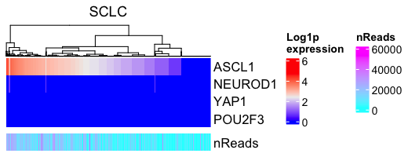

```r
genes <- c("ASCL1", "NEUROD1", "YAP1", "POU2F3")
sce <- sclc[, which(colData(sclc)$nReads > 2000)]
set.seed(1)
inds <- sample(ncol(sce), size = 1000, replace = FALSE)
subsce <- sce[genes, inds]
mat <- log(as.matrix(assay(subsce, "counts")) + 1)
set.seed(1)

filename <- "figures/figure_01_0005.png"
png(file = filename, height = 200, width = 520, res = 100)
#png(file = filename, height = 580, width = 1600, res = 300)
p <- ComplexHeatmap::Heatmap(mat, column_title = "SCLC",
                             name = "Log1p\nexpression", cluster_rows = FALSE,
                             show_row_names = TRUE, row_names_side = "right",
                             show_row_dend = FALSE, show_column_names = FALSE,
                             column_dend_side = "top", show_parent_dend_line = FALSE)
p
dev.off()

# mtx <- t(colData(subsce)$nReads) ; rownames(mtx) <- "nReads"
# q <- ComplexHeatmap::Heatmap(mtx, name = "nReads", show_row_names = TRUE,
#                              row_names_side = "right", show_row_dend = FALSE,
#                              show_column_names = FALSE, show_column_dend = FALSE,
#                              col = circlize::colorRamp2(c(min(mtx), max(mtx)),
#                                                         c("cyan", "magenta")))
# p <- p %v% q
# p
# dev.off()
```

### 5.1.1 Remove variables based on expression profiles

ASURAT function `remove_variables()` removes variable (gene) data such that the numbers of non-zero expressing samples (cells) are less than `min_nsamples`.

```r
sclc <- remove_variables(sce = sclc, min_nsamples = 10)
```

### 5.1.2 Remove samples based on expression profiles

Qualities of sample (cell) data are confirmed based on proper visualization of `colData(sce)`.

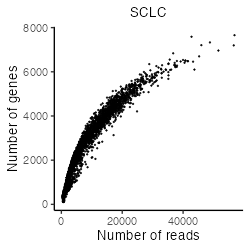

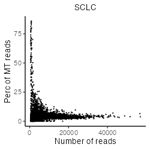

```r
title <- "SCLC"
df <- data.frame(x = colData(sclc)$nReads, y = colData(sclc)$nGenes)
p <- ggplot2::ggplot() +
  ggplot2::geom_point(ggplot2::aes(x = df$x, y = df$y), size = 1, alpha = 1) +
  ggplot2::labs(title = title, x = "Number of reads", y = "Number of genes") +
  ggplot2::theme_classic(base_size = 20) +
  ggplot2::theme(plot.title = ggplot2::element_text(hjust = 0.5, size = 20))
filename <- "figures/figure_01_0010.png"
ggplot2::ggsave(file = filename, plot = p, dpi = 50, width = 5, height = 5)

df <- data.frame(x = colData(sclc)$nReads, y = colData(sclc)$percMT)
p <- ggplot2::ggplot() +
  ggplot2::geom_point(ggplot2::aes(x = df$x, y = df$y), size = 1, alpha = 1) +
  ggplot2::labs(title = title, x = "Number of reads", y = "Perc of MT reads") +
  ggplot2::theme_classic(base_size = 20) +
  ggplot2::theme(plot.title = ggplot2::element_text(hjust = 0.5, size = 20))
filename <- "figures/figure_01_0011.png"
ggplot2::ggsave(file = filename, plot = p, dpi = 50, width = 5, height = 5)
```

ASURAT function `remove_samples()` removes sample (cell) data by setting cutoff values for the metadata.

```r
sclc <- remove_samples(sce = sclc, min_nReads = 1400, max_nReads = 40000,
                       min_nGenes = 1150, max_nGenes = 1e+10,
                       min_percMT = 0, max_percMT = 15)
```

### 5.1.3 Remove variables based on the mean read counts

Qualities of variable (gene) data are confirmed based on proper visualization of `rowData(sce)`.

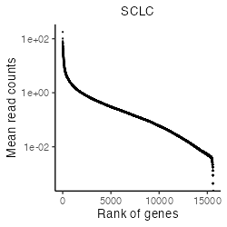

```r
title <- "SCLC"
aveexp <- apply(as.matrix(assay(sclc, "counts")), 1, mean)
df <- data.frame(x = seq_len(nrow(rowData(sclc))),
                 y = sort(aveexp, decreasing = TRUE))
p <- ggplot2::ggplot() + ggplot2::scale_y_log10() +
  ggplot2::geom_point(ggplot2::aes(x = df$x, y = df$y), size = 1, alpha = 1) +
  ggplot2::labs(title = title, x = "Rank of genes", y = "Mean read counts") +
  ggplot2::theme_classic(base_size = 20) +
  ggplot2::theme(plot.title = ggplot2::element_text(hjust = 0.5, size = 20))
filename <- "figures/figure_01_0015.png"
ggplot2::ggsave(file = filename, plot = p, dpi = 50, width = 5, height = 5)
```

ASURAT function `remove_variables_second()` removes variable (gene) data such that the mean read counts across samples are less than `min_meannReads`.

```r
sclc <- remove_variables_second(sce = sclc, min_meannReads = 0.20)
```

```r
dim(sclc)
```

```
[1] 6346 2283
```

## 5.2 Normalize data

Perform `bayNorm()` (Tang et al., Bioinformatics, 2020) for attenuating technical biases with respect to zero inflation and variation of capture efficiencies between samples (cells).

```r
mat <- as.matrix(assay(sclc, "counts"))
BETA <- bayNorm::BetaFun(Data = mat, MeanBETA = 0.06)
bayout <- bayNorm::bayNorm(mat, BETA_vec = BETA[["BETA"]], mode_version = TRUE)
assay(sclc, "normalized") <- bayout$Bay_out
```

Perform log-normalization with a pseudo count.

```r
assay(sclc, "logcounts") <- log(assay(sclc, "normalized") + 1)
```

Center row data.

```r
mat <- assay(sclc, "logcounts")
assay(sclc, "centered") <- sweep(mat, 1, apply(mat, 1, mean), FUN = "-")
```

Set gene expression data into `altExp(sce)`.

```r
sname <- "logcounts"
altExp(sclc, sname) <- SummarizedExperiment(list(counts = assay(sclc, sname)))
```

Add ENTREZ Gene IDs to `rowData(sce)`.

```r
dictionary <- AnnotationDbi::select(org.Hs.eg.db::org.Hs.eg.db,
                                    key = rownames(sclc),
                                    columns = "ENTREZID", keytype = "SYMBOL")
dictionary <- dictionary[!duplicated(dictionary$SYMBOL), ]
rowData(sclc)$geneID <- dictionary$ENTREZID
```

# 6 Multifaceted sign analysis

Infer cell or disease types, biological functions, and signaling pathway activity at the single-cell level by inputting related databases.

ASURAT transforms centered read count tables to functional feature matrices, termed sign-by-sample matrices (SSMs). Using SSMs, perform unsupervised clustering of samples (cells).

## 6.1 Compute correlation matrices

Prepare correlation matrices of gene expressions.

```r
mat <- t(as.matrix(assay(sclc, "centered")))
cormat <- cor(mat, method = "spearman")
```

## 6.2 Load databases

Load databases.

```r
urlpath <- "https://github.com/keita-iida/ASURATDB/blob/main/genes2bioterm/"
load(url(paste0(urlpath, "20201213_human_DO.rda?raw=TRUE")))         # DO
load(url(paste0(urlpath, "20201213_human_GO_red.rda?raw=TRUE")))     # GO
load(url(paste0(urlpath, "20201213_human_KEGG.rda?raw=TRUE")))       # KEGG
```

The reformatted knowledge-based data were available from the following repositories:

- [DOI:10.6084/m9.figshare.19102598](https://figshare.com/s/0599d2de970c2deb675c)
- [Github ASURATDB](https://github.com/keita-iida/ASURATDB)

Add formatted databases to `metadata(sce)$sign`.

```r
sclcs <- list(DO = sclc, GO = sclc, KG = sclc)
metadata(sclcs$DO) <- list(sign = human_DO[["disease"]])
metadata(sclcs$GO) <- list(sign = human_GO[["BP"]])
metadata(sclcs$KG) <- list(sign = human_KEGG[["pathway"]])
```

## 6.3 Create signs

ASURAT function `remove_signs()` redefines functional gene sets for the input database by removing genes, which are not included in `rownames(sce)`, and further removes biological terms including too few or too many genes.

```r
sclcs$DO <- remove_signs(sce = sclcs$DO, min_ngenes = 2, max_ngenes = 1000)
sclcs$GO <- remove_signs(sce = sclcs$GO, min_ngenes = 2, max_ngenes = 1000)
sclcs$KG <- remove_signs(sce = sclcs$KG, min_ngenes = 2, max_ngenes = 1000)
```

```r
set.seed(1)
sclcs$DO <- cluster_genesets(sce = sclcs$DO, cormat = cormat,
                             th_posi = 0.28, th_nega = -0.22)
set.seed(1)
sclcs$GO <- cluster_genesets(sce = sclcs$GO, cormat = cormat,
                             th_posi = 0.20, th_nega = -0.20)
set.seed(1)
sclcs$KG <- cluster_genesets(sce = sclcs$KG, cormat = cormat,
                             th_posi = 0.17, th_nega = -0.16)
```

ASURAT function `create_signs()` creates signs by the following criteria:

1. the number of genes in SCG>= `min_cnt_strg` (the default value is 2) and
2. the number of genes in VCG>= `min_cnt_vari` (the default value is 2),

which are independently applied to SCGs and VCGs, respectively.

```r
sclcs$DO <- create_signs(sce = sclcs$DO, min_cnt_strg = 2, min_cnt_vari = 2)
sclcs$GO <- create_signs(sce = sclcs$GO, min_cnt_strg = 3, min_cnt_vari = 3)
sclcs$KG <- create_signs(sce = sclcs$KG, min_cnt_strg = 3, min_cnt_vari = 3)
```

## 6.4 Select signs

If signs have semantic similarity information, one can use ASURAT function `remove_signs_redundant()` for removing redundant sings using the semantic similarity matrices.

```r
simmat <- human_DO$similarity_matrix$disease
sclcs$DO <- remove_signs_redundant(sce = sclcs$DO, similarity_matrix = simmat,
                                   threshold = 0.82, keep_rareID = TRUE)

simmat <- human_GO$similarity_matrix$BP
sclcs$GO <- remove_signs_redundant(sce = sclcs$GO, similarity_matrix = simmat,
                                   threshold = 0.80, keep_rareID = TRUE)
```

ASURAT function `remove_signs_manually()` removes signs by specifying IDs (e.g., `GOID:XXX`) or descriptions (e.g., `metabolic`) using `grepl()`.

```r
keywords <- "Covid|COVID"
sclcs$KG <- remove_signs_manually(sce = sclcs$KG, keywords = keywords)
```

## 6.5 Create sign-by-sample matrices

- `assayNames(new_sce)`: counts (SSM whose entries are termed sign scores),
- `names(colData(new_sce))`: nReads, nGenes, percMT,
- `names(rowData(new_sce))`: ParentSignID, Description, CorrGene, etc.,
- `names(metadata(new_sce))`: sign_SCG, sign_VCG, etc.,
- `altExpNames(new_sce)`: something if there is data in `altExp(sce)`.

```r
sclcs$DO <- makeSignMatrix(sce = sclcs$DO, weight_strg = 0.5, weight_vari = 0.5)
sclcs$GO <- makeSignMatrix(sce = sclcs$GO, weight_strg = 0.5, weight_vari = 0.5)
sclcs$KG <- makeSignMatrix(sce = sclcs$KG, weight_strg = 0.5, weight_vari = 0.5)
```

## 6.6 Reduce dimensions of sign-by-sample matrices

Perform diffusion map for the SSM for disease.

```r
set.seed(1)
res <- destiny::DiffusionMap(t(assay(sclcs$DO, "counts")))
reducedDim(sclcs$DO, "DMAP") <- res@eigenvectors
```

Perform t-distributed stochastic neighbor embedding for the SSMs for biological process and signaling pathway.

```r
dbs <- c("GO", "KG")
for(i in seq_along(dbs)){
  set.seed(1)
  mat <- t(as.matrix(assay(sclcs[[dbs[i]]], "counts")))
  res <- Rtsne::Rtsne(mat, dim = 2, pca = TRUE, initial_dims = 100)
  reducedDim(sclcs[[dbs[i]]], "TSNE") <- res[["Y"]]
}
```

Show the results of dimensional reduction in low-dimensional spaces. Use ASURAT function `plot_dataframe3D()` for plotting three-dimensional data. See `?plot_dataframe3D` for details.

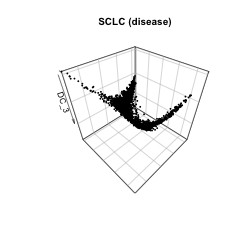

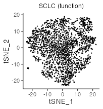

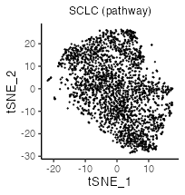

```r
# DO
df <- as.data.frame(reducedDim(sclcs$DO, "DMAP"))[, seq_len(3)]
filename <- "figures/figure_01_0020.png"
png(file = filename, height = 250, width = 250, res = 50)
plot_dataframe3D(dataframe3D = df, theta = -45, phi = 220, title = "SCLC (disease)",
                 xlabel = "DC_1", ylabel = "DC_2", zlabel = "DC_3")
dev.off()

# GO
df <- as.data.frame(reducedDim(sclcs$GO, "TSNE"))
p <- ggplot2::ggplot() +
  ggplot2::geom_point(ggplot2::aes(x = df[, 1], y = df[, 2]),
                      color = "black", size = 1, alpha = 1) +
  ggplot2::labs(title = "SCLC (function)", x = "tSNE_1", y = "tSNE_2") +
  ggplot2::theme_classic(base_size = 20) +
  ggplot2::theme(plot.title = ggplot2::element_text(hjust = 0.5, size = 18))
filename <- "figures/figure_01_0021.png"
ggplot2::ggsave(file = filename, plot = p, dpi = 50, width = 4.1, height = 4.3)

# KEGG
df <- as.data.frame(reducedDim(sclcs$KG, "TSNE"))
p <- ggplot2::ggplot() +
  ggplot2::geom_point(ggplot2::aes(x = df[, 1], y = df[, 2]),
                      color = "black", size = 1, alpha = 1) +
  ggplot2::labs(title = "SCLC (pathway)", x = "tSNE_1", y = "tSNE_2") +
  ggplot2::theme_classic(base_size = 20) +
  ggplot2::theme(plot.title = ggplot2::element_text(hjust = 0.5, size = 18))
filename <- "figures/figure_01_0022.png"
ggplot2::ggsave(file = filename, plot = p, dpi = 50, width = 4.1, height = 4.3)
```

## 6.7 Cluster cells

```r
# Load customized plot functions.
source("../R/plot_additional.R")
```

### 6.7.1 Use MERLoT functions

MERLoT is a useful package detecting a tree-like topology in data space. Using MERLoT, one can cluster cells by allocating individual cells to the branches of the data manifold and define pseudotimes along the branches.

```r
# Preparation
res <- list()
dmap <- reducedDims(sclcs$DO)$DMAP[, seq_len(3)]
mat <- t(as.matrix(assay(sclcs$DO, "counts")))
# ScaffoldTree
res[[1]] <- merlot::CalculateScaffoldTree(CellCoordinates = dmap,
                                          NEndpoints = 3, random_seed = 1)
# ElasticTree
res[[2]] <- merlot::CalculateElasticTree(ScaffoldTree = res[[1]], N_yk = 30)
# SignsSpaceEmbedding
res[[3]] <- merlot::GenesSpaceEmbedding(ExpressionMatrix = mat,
                                        ElasticTree = res[[2]], NCores = 3)
# Pseudotime in high dimensional space
res[[4]] <- merlot::CalculatePseudotimes(InputTree = res[[2]], T0 = 1)
# Cluster cells based on tree branches embedded in high dimensional space.
labels <- res[[3]]$Cells2Branches
# Store the results
ngroups <- length(unique(sort(labels)))
colData(sclcs$DO)$merlot_clusters <- factor(labels, levels = seq_len(ngroups))
names(res) <- c("ScaffoldTree", "ElasticTree", "SignsSpaceEmbedding",
                "Pseudotimes_highdim")
metadata(sclcs$DO)$merlot <- res
```

Show elastic trees and pseudotimes, embedded in the original sign score space, in diffusion map spaces.

```r
# Elastic tree
labels <- colData(sclcs$DO)$merlot_clusters
colors <- scales::hue_pal()(length(unique(labels)))[labels]
filename <- "figures/figure_01_0025.png"
png(file = filename, height = 250, width = 250, res = 50)
plot_elasticTree3D(ElasticTree = metadata(sclcs$DO)$merlot$ElasticTree,
                   labels = labels, colors = colors, theta = -45, phi = 220,
                   title = "SCLC (disease)", xlabel = "DC_1", ylabel = "DC_2",
                   zlabel = "DC_3")
dev.off()
# Pseudotime
filename <- "figures/figure_01_0026.png"
png(file = filename, height = 250, width = 250, res = 50)
plot_pseudotime3D(ElasticTree = metadata(sclcs$DO)$merlot$ElasticTree,
                  Pseudotimes = metadata(sclcs$DO)$merlot$Pseudotimes_highdim,
                  labels = labels, colors = colors, theta = -45, phi = 220,
                  title = "SCLC (disease)", xlabel = "DC_1", ylabel = "DC_2",
                  zlabel = "DC_3")
dev.off()
```

Show clustering results in low-dimensional spaces.

[figure not shown]

[figure not shown]

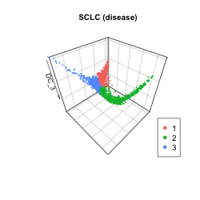

```r
labels <- colData(sclcs$DO)$merlot_clusters
df <- as.data.frame(reducedDim(sclcs$DO, "DMAP"))
filename <- "figures/figure_01_0030.png"
png(file = filename, height = 250, width = 250, res = 50)
plot_dataframe3D(dataframe3D = df, labels = labels,
                 theta = -45, phi = 220, title = "SCLC (disease)",
                 xlabel = "DC_1", ylabel = "DC_2", zlabel = "DC_3")
dev.off()
```

### 6.7.2 Use Seurat functions

To date (December, 2021), one of the most useful clustering methods in scRNA-seq data analysis is a combination of a community detection algorithm and graph-based unsupervised clustering, developed in Seurat package.

Here, our strategy is as follows:

1. convert SingleCellExperiment objects into Seurat objects (note that `rowData()` and `colData()` must have data),
2. perform `ScaleData()`, `RunPCA()`, `FindNeighbors()`, and `FindClusters()`,
3. convert Seurat objects into temporal SingleCellExperiment objects `temp`,
4. add `colData(temp)$seurat_clusters` into `colData(sce)$seurat_clusters`.

```r
resolutions <- c(0.10, 0.20)
dims <- list(seq_len(40), seq_len(30))
dbs <- c("GO", "KG")
for(i in seq_along(dbs)){
  surt <- Seurat::as.Seurat(sclcs[[dbs[i]]], counts = "counts", data = "counts")
  mat <- as.matrix(assay(sclcs[[dbs[i]]], "counts"))
  surt[["SSM"]] <- Seurat::CreateAssayObject(counts = mat)
  Seurat::DefaultAssay(surt) <- "SSM"
  surt <- Seurat::ScaleData(surt, features = rownames(surt))
  surt <- Seurat::RunPCA(surt, features = rownames(surt))
  surt <- Seurat::FindNeighbors(surt, reduction = "pca", dims = dims[[i]])
  surt <- Seurat::FindClusters(surt, resolution = resolutions[i])
  temp <- Seurat::as.SingleCellExperiment(surt)
  colData(sclcs[[dbs[i]]])$seurat_clusters <- colData(temp)$seurat_clusters
}
```

Show the clustering results in low-dimensional spaces.

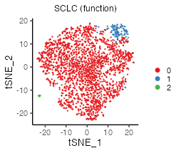

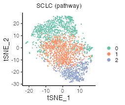

```r
titles <- c("SCLC (function)", "SCLC (pathway)")
dbs <- c("GO", "KG")
for(i in seq_along(dbs)){
  labels <- colData(sclcs[[dbs[i]]])$seurat_clusters
  df <- as.data.frame(reducedDim(sclcs[[dbs[i]]], "TSNE"))
  p <- ggplot2::ggplot() +
    ggplot2::geom_point(ggplot2::aes(x = df[, 1], y = df[, 2], color = labels),
                        size = 1, alpha = 1) +
    ggplot2::labs(title = titles[i], x = "tSNE_1", y = "tSNE_2", color = "") +
    ggplot2::theme_classic(base_size = 20) +
    ggplot2::theme(plot.title = ggplot2::element_text(hjust = 0.5, size = 18)) +
    ggplot2::guides(colour = ggplot2::guide_legend(override.aes = list(size = 4)))
  if(i == 1){
    p <- p + ggplot2::scale_colour_brewer(palette = "Set1")
  }else if(i == 2){
    p <- p + ggplot2::scale_colour_brewer(palette = "Set2")
  }
  filename <- sprintf("figures/figure_01_%04d.png", 30 + i)
  ggplot2::ggsave(file = filename, plot = p, dpi = 50, width = 5.1, height = 4.3)
}
```

### 6.7.3 Cell cycle inference using Seurat functions

If there is gene expression data in `altExp(sce)`, we can easily infer cell cycle phases by using Seurat functions in the similar manner as above.

```r
surt <- Seurat::as.Seurat(sclcs$DO, counts = "counts", data = "counts")
mat <- as.matrix(assay(altExp(sclcs$DO), "counts"))
surt[["GEM"]] <- Seurat::CreateAssayObject(counts = mat)
Seurat::DefaultAssay(surt) <- "GEM"
surt <- Seurat::ScaleData(surt, features = rownames(surt))
surt <- Seurat::RunPCA(surt, features = rownames(surt))
surt <- Seurat::CellCycleScoring(surt, s.features = Seurat::cc.genes$s.genes,
                                 g2m.features = Seurat::cc.genes$g2m.genes)
temp <- Seurat::as.SingleCellExperiment(surt)
colData(sclcs$DO)$Phase <- colData(temp)$Phase
```

Show cell cycle phases in low-dimensional spaces.

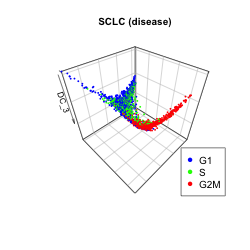

```r
labels <- factor(colData(sclcs$DO)$Phase, levels = unique(colData(sclcs$DO)$Phase))
colors <- colData(sclcs$DO)$Phase
colors[which(colors == "G1")] <- rainbow(3)[3]
colors[which(colors == "S")] <- rainbow(3)[2]
colors[which(colors == "G2M")] <- rainbow(3)[1]
df <- as.data.frame(reducedDim(sclcs$DO, "DMAP"))
filename <- "figures/figure_01_0035.png"
png(file = filename, height = 250, width = 250, res = 50)
plot_dataframe3D(dataframe3D = df, labels = labels, colors = colors,
                 theta = -45, phi = 220, title = "SCLC (disease)",
                 xlabel = "DC_1", ylabel = "DC_2", zlabel = "DC_3")
dev.off()

# df$label <- labels ; df$color <- colors ; df <- df[order(df$label), ]
# filename <- "figures/figure_01_0036.png"
# png(file = filename, height = 1500, width = 1500, res = 300)
# scatter3D(df[, 1], df[, 2], df[, 3], main = title, xlab = xlabel,
#           ylab = ylabel, zlab = zlabel, box = F, bty = "b2", axes = F,
#           nticks = 0, theta = theta, phi = phi, pch = 16, cex = 0.5,
#           alpha = 1.0, col = df$color, colvar = NA, colkey = FALSE)
# graphics::legend("bottomright", legend=unique(df$label), pch = 16,
#                  col = unique(df$color), cex = 1.2, inset = c(0.02))
# dev.off()
```

## 6.8 Investigate significant signs

Significant signs are analogous to differentially expressed genes but bear biological meanings. Note that naïve usages of statistical tests should be avoided because the row vectors of SSMs are centered.

Instead, ASURAT function `compute_sepI_all()` computes separation indices for each cluster against the others. Briefly, a separation index “sepI”, ranging from -1 to 1, is a nonparametric measure of significance of a given sign score for a given subpopulation. The larger (resp. smaller) sepI is, the more reliable the sign is as a positive (resp. negative) marker for the cluster.

```r
for(i in seq_along(sclcs)){
  set.seed(1)
  if(i == 1){
    labels <- colData(sclcs[[i]])$merlot_clusters
  }else{
    labels <- colData(sclcs[[i]])$seurat_clusters
  }
  sclcs[[i]] <- compute_sepI_all(sce = sclcs[[i]], labels = labels,
                                 nrand_samples = NULL)
}

sclcs_LabelDO_SignGO <- sclcs$GO
metadata(sclcs_LabelDO_SignGO)$marker_signs <- NULL
set.seed(1)
sclcs_LabelDO_SignGO <- compute_sepI_all(sce = sclcs_LabelDO_SignGO,
                                         labels = colData(sclcs$DO)$merlot_clusters,
                                         nrand_samples = NULL)

sclcs_LabelDO_SignKG <- sclcs$KG
metadata(sclcs_LabelDO_SignKG)$marker_signs <- NULL
set.seed(1)
sclcs_LabelDO_SignKG <- compute_sepI_all(sce = sclcs_LabelDO_SignKG,
                                         labels = colData(sclcs$DO)$merlot_clusters,
                                         nrand_samples = NULL)
```

## 6.9 Investigate significant genes

### 6.9.1 Use Seurat function

To date (December, 2021), one of the most useful methods of multiple statistical tests in scRNA-seq data analysis is to use a Seurat function `FindAllMarkers()`.

If there is gene expression data in `altExp(sce)`, one can investigate differentially expressed genes by using Seurat functions in the similar manner as described before.

```r
set.seed(1)
surt <- Seurat::as.Seurat(sclcs$DO, counts = "counts", data = "counts")
mat <- as.matrix(assay(altExp(sclcs$DO), "counts"))
surt[["GEM"]] <- Seurat::CreateAssayObject(counts = mat)
Seurat::DefaultAssay(surt) <- "GEM"
surt <- Seurat::SetIdent(surt, value = "merlot_clusters")
res <- Seurat::FindAllMarkers(surt, only.pos = TRUE,
                              min.pct = 0.25, logfc.threshold = 0.25)
metadata(sclcs$DO)$marker_genes$all <- res
```

## 6.10 Multifaceted analysis

Simultaneously analyze multiple sign-by-sample matrices, which helps us characterize individual samples (cells) from multiple biological aspects.

ASURAT function `plot_multiheatmaps()` shows heatmaps (ComplexHeatmap object) of sign scores and gene expression levels (if there are), where rows and columns stand for sign (or gene) and sample (cell), respectively.

First, remove unrelated signs by setting keywords, followed by selecting top significant signs and genes for the clustering results with respect to separation index and p-value, respectively.

```r
# Significant signs
marker_signs <- list()
keys <- "cervical|Oocyte|cycle"
for(i in seq_along(sclcs)){
  if(i == 1){
    marker_signs[[i]] <- metadata(sclcs[[i]])$marker_signs$all
  }else if(i == 2){
    marker_signs[[i]] <- metadata(sclcs_LabelDO_SignGO)$marker_signs$all
  }else if(i == 3){
    marker_signs[[i]] <- metadata(sclcs_LabelDO_SignKG)$marker_signs$all
  }
  marker_signs[[i]] <- marker_signs[[i]][!grepl(keys, marker_signs[[i]]$Description), ]
  marker_signs[[i]] <- dplyr::group_by(marker_signs[[i]], Ident_1)
  marker_signs[[i]] <- dplyr::slice_max(marker_signs[[i]], sepI, n = 1)
  marker_signs[[i]] <- dplyr::slice_min(marker_signs[[i]], Rank, n = 1)
}
# Significant genes
marker_genes_DO <- metadata(sclcs$DO)$marker_genes$all
marker_genes_DO <- dplyr::group_by(marker_genes_DO, cluster)
marker_genes_DO <- dplyr::slice_min(marker_genes_DO, p_val_adj, n = 5)
marker_genes_DO <- dplyr::slice_max(marker_genes_DO, avg_log2FC, n = 5)
```

Then, prepare arguments.

```r
# ssm_list
sces_sub <- list() ; ssm_list <- list()
for(i in seq_along(sclcs)){
  sces_sub[[i]] <- sclcs[[i]][rownames(sclcs[[i]]) %in% marker_signs[[i]]$SignID, ]
  ssm_list[[i]] <- assay(sces_sub[[i]], "counts")
}
names(ssm_list) <- c("SSM_disease", "SSM_function", "SSM_pathway")
# gem_list
expr_sub <- altExp(sclcs$DO, "logcounts")
expr_sub <- expr_sub[rownames(expr_sub) %in% marker_genes_DO$gene]
gem_list <- list(x = t(scale(t(as.matrix(assay(expr_sub, "counts"))))))
names(gem_list) <- "Scaled\nLogExpr"
# ssmlabel_list
labels <- list() ; ssmlabel_list <- list()
tmp <- colData(sces_sub[[1]])$merlot_clusters
labels[[1]] <- data.frame(label = colData(sces_sub[[1]])$merlot_clusters)
n_groups <- length(unique(tmp))
labels[[1]]$color <- scales::hue_pal()(n_groups)[tmp]
ssmlabel_list[[1]] <- labels[[1]]
ssmlabel_list[[2]] <- data.frame(label = NA, color = NA)
ssmlabel_list[[3]] <- data.frame(label = NA, color = NA)
names(ssmlabel_list) <- c("Label_disease", NA, NA)
# gemlabel_list
mycolor <- colData(sclcs$DO)$Phase
mycolor[mycolor == "G1"] <- 3
mycolor[mycolor == "S"] <- 2
mycolor[mycolor == "G2M"] <- 1
label_CC <- data.frame(label = colData(sclcs$DO)$Phase,
                       color = rainbow(3)[as.integer(mycolor)])
label_CC$label <- factor(label_CC$label, levels = c("G1", "S", "G2M"))
gemlabel_list <- list(CellCycle = label_CC)
```

**Tips:** If one would like to omit some color labels (e.g., labels[[3]]), set the argument as follows:

```r
ssmlabel_list[[2]] <- data.frame(label = NA, color = NA)
ssmlabel_list[[3]] <- data.frame(label = NA, color = NA)
```

Finally, plot heatmaps for the selected signs and genes.

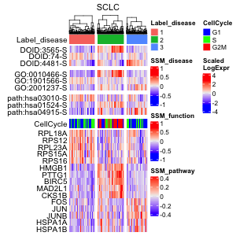

```r
filename <- "figures/figure_01_0040.png"
#png(file = filename, height = 1600, width = 1500, res = 300)
png(file = filename, height = 300, width = 300, res = 60)
set.seed(1)
title <- "SCLC"
plot_multiheatmaps(ssm_list = ssm_list, gem_list = gem_list,
                   ssmlabel_list = ssmlabel_list, gemlabel_list = gemlabel_list,
                   nrand_samples = 500, show_row_names = TRUE, title = title)
dev.off()
```

Show violin plots for the sign score distributions across cell type-related clusters.

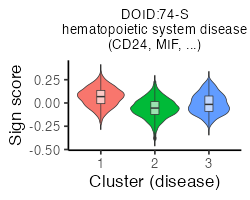

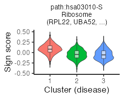

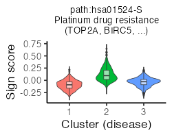

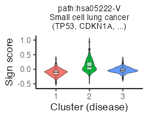

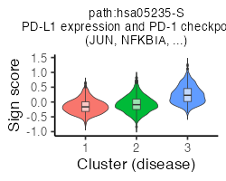

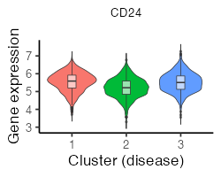

```r
labels <- colData(sclcs$DO)$merlot_clusters
vlist <- list(c("DO", "DOID:74-S",
                "hematopoietic system disease\n(CD24, MIF, ...)"),
              c("KG", "path:hsa03010-S",
                "Ribosome\n(RPL22, UBA52, ...)"),
              c("KG", "path:hsa01524-S",
                "Platinum drug resistance\n(TOP2A, BIRC5, ...)"),
              c("KG", "path:hsa05222-V",
                "Small cell lung cancer\n(TP53, CDKN1A, ...)"),
              c("KG", "path:hsa05235-S",
                "PD-L1 expression and PD-1 checkpoint...\n(JUN, NFKBIA, ...)"),
              c("GE", "CD24", ""))
xlabel <- "Cluster (disease)"
for(i in seq_along(vlist)){
  if(vlist[[i]][1] == "GE"){
    ind <- which(rownames(altExp(sclcs$DO, "logcounts")) == vlist[[i]][2])
    subsce <- altExp(sclcs$DO, "logcounts")[ind, ]
    df <- as.data.frame(t(as.matrix(assay(subsce, "counts"))))
    ylabel <- "Gene expression"
  }else{
    ind <- which(rownames(sclcs[[vlist[[i]][1]]]) == vlist[[i]][2])
    subsce <- sclcs[[vlist[[i]][1]]][ind, ]
    df <- as.data.frame(t(as.matrix(assay(subsce, "counts"))))
    ylabel <- "Sign score"
  }
  p <- ggplot2::ggplot() +
    ggplot2::geom_violin(ggplot2::aes(x = as.factor(labels), y = df[, 1],
                                      fill = labels), trim = FALSE, size = 0.5) +
    ggplot2::geom_boxplot(ggplot2::aes(x = as.factor(labels), y = df[, 1]),
                          width = 0.15, alpha = 0.6) +
    ggplot2::labs(title = paste0(vlist[[i]][2], "\n", vlist[[i]][3]),
                  x = xlabel, y = ylabel, fill = "Cluster") +
    ggplot2::theme_classic(base_size = 25, base_family = "Helvetica") +
    ggplot2::theme(plot.title = ggplot2::element_text(hjust = 0.5, size = 20),
                   legend.position = "none") +
    ggplot2::scale_fill_hue()
  filename <- sprintf("figures/figure_01_%04d.png", 49 + i)
  ggplot2::ggsave(file = filename, plot = p, dpi = 50, width = 5, height = 4)
}
```

Show pseudotime course plots with elastic tree for sign score distributions.

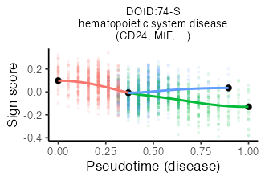

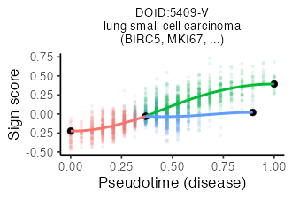

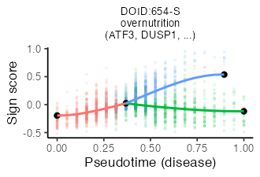

```r
vlist <- list(c("DO", "DOID:74-S",
                "hematopoietic system disease\n(CD24, MIF, ...)"),
              c("DO", "DOID:5409-V",
                "lung small cell carcinoma\n(BIRC5, MKI67, ...)"),
              c("DO", "DOID:654-S",
                "overnutrition\n(ATF3, DUSP1, ...)"))
labels <- colData(sclcs$DO)$merlot_clusters
n_groups <- length(unique(labels))
for(i in seq_along(vlist)){
  p <- plot_pseudotimecourse_wTree(
    sce = sclcs[[vlist[[i]][1]]], signID = vlist[[i]][2],
    ElasticTree = metadata(sclcs$DO)$merlot$ElasticTree,
    SignsSpaceEmbedding = metadata(sclcs$DO)$merlot$SignsSpaceEmbedding,
    Pseudotimes = metadata(sclcs$DO)$merlot$Pseudotimes_highdim,
    labels = labels, range_y = "cells")
  p <- p + ggplot2::scale_color_manual(values = scales::hue_pal()(n_groups)) +
    ggplot2::labs(title = paste0(vlist[[i]][2], "\n", vlist[[i]][3]),
                  x = "Pseudotime (disease)", y = "Sign score", color = "") +
    ggplot2::theme_classic(base_size = 25, base_family = "Helvetica") +
    ggplot2::theme(plot.title = ggplot2::element_text(hjust = 0.5, size = 20),
                   legend.position = "none")
  filename <- sprintf("figures/figure_01_%04d.png", 59 + i)
  ggplot2::ggsave(file = filename, plot = p, dpi = 50, width = 6.6, height = 4.5)
}
```

Show pseudotime course plots without elastic tree for sign score distributions.

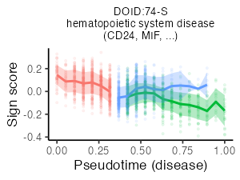

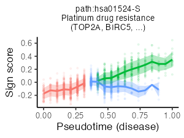

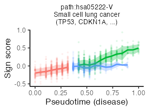

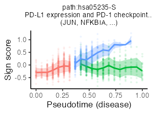

```r
vlist <- list(c("DO", "DOID:74-S",
                "hematopoietic system disease\n(CD24, MIF, ...)"),
              c("KG", "path:hsa01524-S",
                "Platinum drug resistance\n(TOP2A, BIRC5, ...)"),
              c("KG", "path:hsa05222-V",
                "Small cell lung cancer\n(TP53, CDKN1A, ...)"),
              c("KG", "path:hsa05235-S",
                "PD-L1 expression and PD-1 checkpoint...\n(JUN, NFKBIA, ...)"))
for(i in seq_along(vlist)){
  p <- plot_pseudotimecourse_woTree(
    sce = sclcs[[vlist[[i]][1]]], signID = vlist[[i]][2],
    Pseudotimes = metadata(sclcs$DO)$merlot$Pseudotimes_highdim,
    range_y = "cells")
  p <- p + ggplot2::scale_colour_hue() +
    ggplot2::labs(title = paste0(vlist[[i]][2], "\n", vlist[[i]][3]),
                  x = "Pseudotime (disease)", y = "Sign score", fill = "") +
    ggplot2::theme_classic(base_size = 25, base_family = "Helvetica") +
    ggplot2::theme(plot.title = ggplot2::element_text(hjust = 0.5, size = 20),
                   legend.position = "none")
  filename <- sprintf("figures/figure_01_%04d.png", 69 + i)
  ggplot2::ggsave(file = filename, plot = p, dpi = 50, width = 6, height = 4.5)
}
```

## 6.11 Infer cell state

```r
cell_state <- c("SCLC (Ribosome active)", "SCLC (Platinum resistance)",
                "SCLC (PD-L1 expression)")
colData(sclcs$DO)$cell_state <- as.character(colData(sclcs$DO)$merlot_clusters)
colData(sclcs$DO)$cell_type[colData(sclcs$DO)$cell_state == 1] <- cell_state[1]
colData(sclcs$DO)$cell_type[colData(sclcs$DO)$cell_state == 2] <- cell_state[2]
colData(sclcs$DO)$cell_type[colData(sclcs$DO)$cell_state == 3] <- cell_state[3]
```

Show the annotation results in low-dimensional spaces.

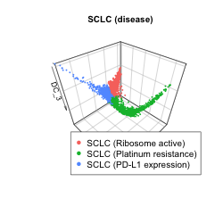

```r
labels <- factor(colData(sclcs$DO)$cell_type, levels = cell_state)
df <- as.data.frame(reducedDim(sclcs$DO, "DMAP"))
filename <- "figures/figure_01_0080.png"
png(file = filename, height = 250, width = 250, res = 50)
plot_dataframe3D(dataframe3D = df, labels = labels,
                 theta = -45, phi = 220, title = "SCLC (disease)",
                 xlabel = "DC_1", ylabel = "DC_2", zlabel = "DC_3")
dev.off()
```

# 7 Using the existing softwares

## 7.1 Seurat

Load the data (see here).

```r
sclc <- readRDS("backup/01_003_sclc_normalized.rds")
```

Create Seurat objects.

```r
sclc <- Seurat::CreateSeuratObject(counts = as.matrix(assay(sclc, "counts")),
                                   project = "SCLC")
```

### 7.1.1 Perform Seurat preprocessing

According to the Seurat protocol, normalize data, perform variance stabilizing transform by setting the number of variable feature, scale data, and reduce dimension using principal component analysis.

```r
# Normalization
sclc <- Seurat::NormalizeData(sclc, normalization.method = "LogNormalize")
# Variance stabilizing transform
n <- round(0.2 * ncol(sclc))
sclc <- Seurat::FindVariableFeatures(sclc, selection.method = "vst", nfeatures = n)
# Scale data
sclc <- Seurat::ScaleData(sclc)
# Principal component analysis
sclc <- Seurat::RunPCA(sclc, features = Seurat::VariableFeatures(sclc))
```

### 7.1.2 Cluster cells

Compute the cumulative sum of variances, which is used for determining the number of the principal components (PCs).

```r
pc <- which(cumsum(sclc@reductions[["pca"]]@stdev) /
              sum(sclc@reductions[["pca"]]@stdev) > 0.9)[1]
```

Perform cell clustering.

```r
# Create k-nearest neighbor graph.
sclc <- Seurat::FindNeighbors(sclc, reduction = "pca", dim = seq_len(pc))
# Cluster cells.
sclc <- Seurat::FindClusters(sclc, resolution = 0.1)
# Run t-SNE.
sclc <- Seurat::RunTSNE(sclc, dims.use = seq_len(2), reduction = "pca",
                        dims = seq_len(pc), do.fast = FALSE, perplexity = 30)
# Run UMAP.
sclc <- Seurat::RunUMAP(sclc, dims = seq_len(pc))
```

Show the clustering results.

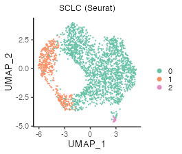

```r
title <- "SCLC (Seurat)"
labels <- sclc@meta.data[["seurat_clusters"]]
mycolor <- scales::brewer_pal(palette = "Set2")(4)
mycolor <- c("0" = mycolor[1], "1" = mycolor[2], "2" = mycolor[4])
df <- sclc@reductions[["umap"]]@cell.embeddings
p <- ggplot2::ggplot() +
  ggplot2::geom_point(ggplot2::aes(x = df[, 1], y = df[, 2], color = labels),
                      size = 1, alpha = 1) +
  ggplot2::labs(title = title, x = "UMAP_1", y = "UMAP_2", color = "") +
  ggplot2::theme_classic(base_size = 20) +
  ggplot2::theme(plot.title = ggplot2::element_text(hjust = 0.5, size = 18)) +
  ggplot2::scale_color_manual(values = mycolor) +
  ggplot2::guides(colour = ggplot2::guide_legend(override.aes = list(size = 4)))
filename <- "figures/figure_01_0230.png"
ggplot2::ggsave(file = filename, plot = p, dpi = 50, width = 5.3, height = 4.5)
```

### 7.1.3 Find differentially expressed genes

Find differentially expressed genes.

```r
sclc@misc$stat <- Seurat::FindAllMarkers(sclc, only.pos = TRUE, min.pct = 0.25,
                                         logfc.threshold = 0.25)
View(sclc@misc$stat[which(sclc@misc$stat$p_val_adj < 10^(-100)), ])
```

### 7.1.4 Cell cycle inference

Assign each cell a cell cycle score using `CellCycleScoring()`. `obj@meta.data[["Phase"]]`.

```r
s.genes <- Seurat::cc.genes$s.genes
g2m.genes <- Seurat::cc.genes$g2m.genes
sclc <- Seurat::CellCycleScoring(sclc, s.features = Seurat::cc.genes$s.genes,
                                 g2m.features = Seurat::cc.genes$g2m.genes)
```

Show the inferred cell cycle phases in low-dimensional spaces.

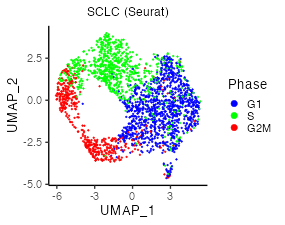

```r
title <- "SCLC (Seurat)"
labels <- factor(sclc@meta.data[["Phase"]], levels = c("G1", "S", "G2M"))
mycolor <- c(rainbow(3)[3], rainbow(3)[2], rainbow(3)[1])
df <- sclc@reductions[["umap"]]@cell.embeddings
p <- ggplot2::ggplot() +
  ggplot2::geom_point(ggplot2::aes(x = df[, 1], y = df[, 2], color = labels),
                      size = 1, alpha = 1) +
  ggplot2::labs(title = title, x = "UMAP_1", y = "UMAP_2", color = "Phase") +
  ggplot2::theme_classic(base_size = 20) +
  ggplot2::theme(plot.title = ggplot2::element_text(hjust = 0.5, size = 18)) +
  ggplot2::scale_color_manual(values = mycolor) +
  ggplot2::guides(colour = ggplot2::guide_legend(override.aes = list(size = 4)))
filename <- "figures/figure_01_0235.png"
ggplot2::ggsave(file = filename, plot = p, dpi = 50, width = 5.7, height = 4.5)
```

### 7.1.5 Enrichment analysis

Perform GO and KEGG enrichment analyses using differentially expressed genes, whose adjusted p-values are<= `padj_cutoff`.

```r
padj_cutoff = 0.01
```

Prepares a list of genes, which is used for an input of `compareCluster()` in clusterProfiler package.

```r
n_groups <- length(unique(sclc@meta.data[["seurat_clusters"]]))
tmp <- sclc@misc[["stat"]]
cluster_names <- as.character(unique(tmp$cluster))
g <- list() ; glist <- list() ; label_names <- c()
for(i in seq_len(n_groups)){
  im1 <- i - 1
  df <- tmp[which(tmp$cluster == im1), ]
  g[[i]] <- df[which(df$p_val_adj <= padj_cutoff), ]$gene
  geneID <- clusterProfiler::bitr(g[[i]], fromType = "SYMBOL",
                                  toType = "ENTREZID",
                                  OrgDb = org.Hs.eg.db::org.Hs.eg.db)$ENTREZID
  glist[[i]] <- geneID
  label_names <- c(label_names, paste("Group_", im1, sep = ""))
}
names(glist) <- label_names
```

Performs `compareCluster()`, which easily compares enriched biological terms across clusters.

```r
sclc@misc[["compareCluster_GO"]] <- clusterProfiler::compareCluster(
  glist, fun = "enrichGO", OrgDb = org.Hs.eg.db::org.Hs.eg.db, ont = "BP",
  pAdjustMethod = "BH", pvalueCutoff = padj_cutoff)

sclc@misc[["compareCluster_KEGG"]] <- clusterProfiler::compareCluster(
  glist, fun = "enrichKEGG", organism = "hsa", keyType = "kegg",
  pAdjustMethod = "BH", pvalueCutoff = padj_cutoff)
#  minGSSize = 10, maxGSSize = 500) # min/max size of genes annotated for testing
```

Show the results of the enrichment analyses.

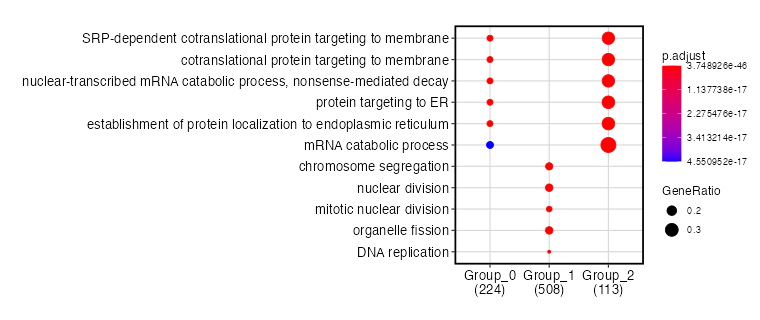

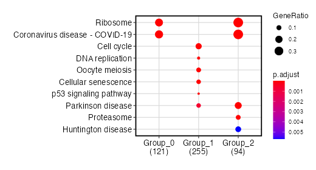

```r
p <- enrichplot::dotplot(sclc@misc[["compareCluster_GO"]], showCategory = 5) +
  ggplot2::theme(panel.grid.major = ggplot2::element_line(size = 0.5,
                                                          color = "grey85"),
                 panel.border = ggplot2::element_rect(color = "black", fill = NA,
                                                      size = 1.5))
filename <- "figures/figure_01_0250.png"
ggplot2::ggsave(file = filename, plot = p, dpi = 80, width = 9.5, height = 4)

p <- enrichplot::dotplot(sclc@misc[["compareCluster_KEGG"]], showCategory = 5) +
  ggplot2::theme(panel.grid.major = ggplot2::element_line(size = 0.5,
                                                          color = "grey85"),
                 panel.border = ggplot2::element_rect(color = "black", fill = NA,
                                                      size = 1.5))
filename <- "figures/figure_01_0251.png"
ggplot2::ggsave(file = filename, plot = p, dpi = 80, width = 6.5, height = 3.5)
```

### 7.1.6 Remove cell cycle

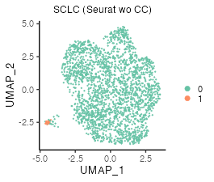

```r
# Regress out the cell cycle effects.
sclc <- Seurat::ScaleData(sclc, vars.to.regress = c("S.Score", "G2M.Score"),
                          features = rownames(sclc))
# Run principal component analysis.
sclc <- Seurat::RunPCA(sclc, features = Seurat::VariableFeatures(sclc))
# Compute the cumulative sum of variances.
pc <- which(cumsum(sclc@reductions[["pca"]]@stdev) /
              sum(sclc@reductions[["pca"]]@stdev) > 0.9)[1]
# Create k-nearest neighbor graph.
sclc <- Seurat::FindNeighbors(sclc, reduction = "pca", dim = seq_len(pc))
# Cluster cells.
sclc <- Seurat::FindClusters(sclc, resolution = 0.1)
# Run t-SNE.
sclc <- Seurat::RunTSNE(sclc, dims.use = seq_len(2), reduction = "pca",
                        dims = seq_len(pc), do.fast = FALSE, perplexity = 30)
# Run UMAP.
sclc <- Seurat::RunUMAP(sclc, dims = seq_len(pc))
# Show the clustering results.
title <- "SCLC (Seurat wo CC)"
labels <- sclc@meta.data[["seurat_clusters"]]
df <- sclc@reductions[["umap"]]@cell.embeddings
p <- ggplot2::ggplot() +
  ggplot2::geom_point(ggplot2::aes(x = df[, 1], y = df[, 2], color = labels),
                      size = 1, alpha = 1) +
  ggplot2::labs(title = title, x = "UMAP_1", y = "UMAP_2", color = "") +
  ggplot2::theme_classic(base_size = 20) +
  ggplot2::theme(plot.title = ggplot2::element_text(hjust = 0.5, size = 18)) +
  ggplot2::scale_color_brewer(palette = "Set2") +
  ggplot2::guides(colour = ggplot2::guide_legend(override.aes = list(size = 4)))
filename <- "figures/figure_01_0260.png"
ggplot2::ggsave(file = filename, plot = p, dpi = 50, width = 5.3, height = 4.5)

labels <- factor(sclc@meta.data[["Phase"]], levels = c("G1", "S", "G2M"))
mycolor <- c(rainbow(3)[3], rainbow(3)[2], rainbow(3)[1])
df <- sclc@reductions[["umap"]]@cell.embeddings
p <- ggplot2::ggplot() +
  ggplot2::geom_point(ggplot2::aes(x = df[, 1], y = df[, 2], color = labels),
                      size = 1, alpha = 1) +
  ggplot2::labs(title = title, x = "UMAP_1", y = "UMAP_2", color = "Phase") +
  ggplot2::theme_classic(base_size = 20) +
  ggplot2::theme(plot.title = ggplot2::element_text(hjust = 0.5, size = 18)) +
  ggplot2::scale_color_manual(values = mycolor) +
  ggplot2::guides(colour = ggplot2::guide_legend(override.aes = list(size = 4)))
filename <- "figures/figure_01_0261.png"
ggplot2::ggsave(file = filename, plot = p, dpi = 50, width = 5.7, height = 4.5)
```